# Text Classification Homework

Dmitri Bobrikov

04 Ноябрь, 2022

## Loading the data

We will start with loading the data

```r
library(readr)
data = read_csv("~/rrrr/cmat/Corona_NLP_train.csv")
head(data)
```

| UserName | ScreenName | Location | TweetAt | OriginalTweet | Sentiment |
| --- | --- | --- | --- | --- | --- |
| 3799 | 48751 | London | 16-03-2020 | @MeNyrbie @Phil_Gahan @Chrisitv https://t.co/iFz9FAn2Pa and https://t.co/xX6ghGFzCC and https://t.co/I2NlzdxNo8 | Neutral |
| 3800 | 48752 | UK | 16-03-2020 | advice Talk to your neighbours family to exchange phone numbers create contact list with phone numbers of neighbours schools employer chemist GP set up online shopping accounts if poss adequate suppli… | Positive |
| 3801 | 48753 | Vagabonds | 16-03-2020 | Coronavirus Australia: Woolworths to give elderly, disabled dedicated shopping hours amid COVID-19 outbreak https://t.co/bInCA9Vp8P | Positive |
| 3802 | 48754 | NA | 16-03-2020 | My food stock is not the only one which is empty...\r\r\n\r\r\nPLEASE, don't panic, THERE WILL BE ENOUGH FOOD FOR EVERYONE if you do not take more than you need. \r\r\nStay calm, stay safe.\r\r\n\r\r\… | Positive |
| 3803 | 48755 | NA | 16-03-2020 | Me, ready to go at supermarket during the #COVID19 outbreak.\r\r\n\r\r\nNot because I'm paranoid, but because my food stock is litteraly empty. The #coronavirus is a serious thing, but please, don't p… | Extremely Negative |
| 3804 | 48756 | UT: 36.319708,-82.363649 | 16-03-2020 | As news of the regions first confirmed COVID-19 case came out of Sullivan County last week, people flocked to area stores to purchase cleaning supplies, hand sanitizer, food, toilet paper and other go… | Positive |

Let’s drop out neutral tweets and group 4 categories into 2: positive and negative

```r
library(dplyr)
library(stringr)
library(stringi)
data = data %>% mutate(OriginalTweet = stri_replace_all_regex(OriginalTweet,
                                  pattern=c("\u0091", "\u0092", "\u0093", "\u0094", "\u0095", "\u0096", "\u0097", "\u0099", "\u0080", "\u0084", "\u009e", "\u009a"),
                                  replacement=c("'", "'", "'", "'", "", "", "", "", "", "", "", ""),
                                  vectorize=FALSE))
data = data %>% filter(Sentiment != "Neutral")
data = data %>%
  mutate(Senti = case_when(Sentiment == "Extremely Positive" ~ "Positive",
                                                Sentiment == "Positive" ~ "Positive",
                                                Sentiment == "Extremely Negative" ~ "Negative",
                                                Sentiment == "Negative" ~ "Negative")) %>%
  select(-Sentiment, -Location, -TweetAt, -ScreenName, -UserName)
```

Let’s check whether we obtained proper results

```r
table(data$Senti)
```

```
##
## Negative Positive
##    15398    18046
```

Yes, everything looks fine!

```r
data = data %>% mutate(doc_id = row_number())
```

Creating doc id’s will help us later

## Text Preprocessing

For the next analysis we need to preprocess our data. We need to tokenize to divide tweets into words as we analyse them separately (for now), it is crucial to lemmatize words to leave only initial form of the word that will simplify the process, deleting stop words is needed to delete the most frequent words that do not make any sense (for example, “the”, “a” and so on), and finally deleting of punctuation and digits is needed because they can disturb our analysis

```r
library(textstem)
library(tidytext)
library(stopwords)

data$OriginalTweet = iconv(data$OriginalTweet, "UTF-8", "UTF-8", sub=' ')

data_lemmas = data %>%
    unnest_tokens(word, OriginalTweet, token="tweets") %>%
    mutate(lem = lemmatize_words(word)) %>%
    filter(! lem %in% stopwords("en")) %>%
    filter(! str_detect(lem, "[0-9]+"))

head(data_lemmas)
```

| Senti | doc_id | word | lem |
| --- | --- | --- | --- |
| Positive | 1 | advice | advice |
| Positive | 1 | talk | talk |
| Positive | 1 | neighbours | neighbour |
| Positive | 1 | family | family |
| Positive | 1 | exchange | exchange |
| Positive | 1 | phone | phone |

We can see that everything works good!

## EDA

### Basic statistics

Corpus size:

```r
data_lemmas  %>% nrow
```

```
## [1] 629198
```

We have 629198 lemmatized words in our corpus.

Vocabulary size:

```r
data_lemmas %>% distinct(lem) %>% nrow
```

```
## [1] 49364
```

We have 49364 distinct lemmatized words in our corpus.

Class distribution:

```r
table(data_lemmas$Senti)
```

```
##
## Negative Positive
##   287616   341582
```

We can see that we have more positive words than negative ones (341582 > 287616)

Covid is cool xo-xo:

[figure not shown]

### Contrastive analysis

```r
library(tidyr)
pos_words = data_lemmas %>% filter(Senti == "Positive") %>% mutate(sentim = "pos")
neg_words = data_lemmas %>% filter(Senti == "Negative") %>% mutate(sentim = "neg")

tweets.lemmas = bind_rows(pos_words, neg_words) %>%
    dplyr::count(lem, sentim) %>%
    spread(sentim, n, fill = 0) %>%
    dplyr::filter(pos > 10 | neg > 10)

head(tweets.lemmas)
```

| lem | neg | pos |
| --- | --- | --- |
| #advertising | 3 | 15 |
| #africa | 11 | 5 |
| #agriculture | 6 | 12 |
| #ai | 7 | 12 |
| #alert | 3 | 29 |
| #amazon | 42 | 46 |

Here we can see the number of the the most frequent words among positive and negative words. We can notice that some words are more frequently used in positive sense while others in negative.

Let’s calculate Dunning log-likelihood (G^2) to see whether words are statistically significantly different between two groups

Function itself:

```r
g2 = function(a, b) {
  c = sum(a)
  d = sum(b)
  E1 = c * ((a + b) / (c + d))
  E2 = d * ((a + b) / (c + d))
  return(2*((a*log(a/E1+1e-7)) + (b*log(b/E2+1e-7))))
}
```

Calculating:

```r
tweets.g2 = tweets.lemmas %>%
    mutate(g2=g2(pos, neg)) %>%
    arrange(desc(g2)) %>%
    mutate(g2 = round(g2, 2))

head(tweets.g2)
```

| lem | neg | pos | g2 |
| --- | --- | --- | --- |
| panic | 2016 | 431 | 1404.45 |
| hand | 405 | 2139 | 1017.39 |
| crisis | 1325 | 278 | 935.01 |
| help | 433 | 2031 | 868.70 |
| thank | 160 | 1214 | 745.17 |
| sanitizer | 426 | 1782 | 678.48 |

We can see that, for example, word “panic” is more frequently used in negative tweets and the difference with positive tweets is huge.

Now let’s proceed to effect size to see for which group words are commonly used. For this purpose we will calculate *log-ratio*

Function itself:

```r
logratio = function(a, b) {
    return(log2((a/sum(a)/(b/sum(b)))))
}
```

Calculating:

```r
tweets.lr = tweets.g2 %>%
    mutate(logodds = logratio(pos, neg))
```

Let’s make a visualisation of the obtained results to see the most different words for positive and negative words

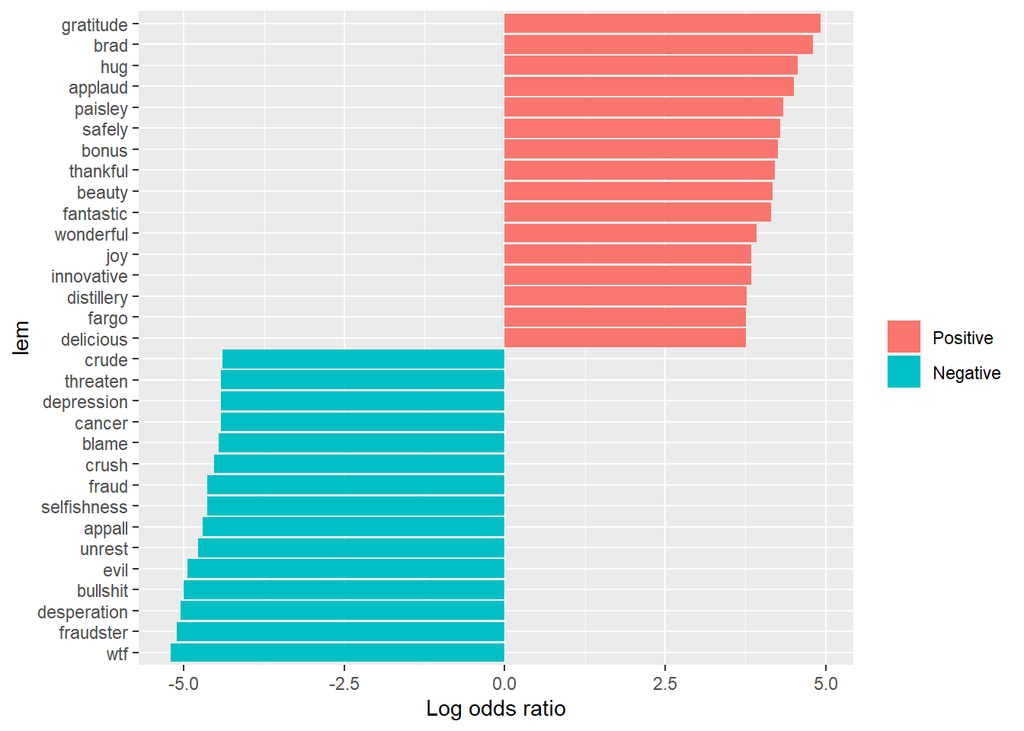

```r
library(ggplot2)
tweets.lr %>%
    filter(pos > 0 & neg > 0) %>%
    group_by(logodds < 0) %>%
    top_n(15, abs(logodds)) %>%
    ungroup() %>%
    mutate(lem = reorder(lem, logodds)) %>%
    ggplot(aes(lem, logodds, fill = logodds < 0)) +
    geom_col(show.legend = TRUE) +
    coord_flip() +
    ylab("Log odds ratio") +
    scale_fill_discrete(name = "", labels = c("Positive", "Negative"))
```

We can see dramatic differences between negative and positive tweets: there are even mentions of diseases in negative tweets. Moreover, “wtf” just describes the general attitude about COVID-19 for all people who tweeted negatively, I guess…

## Preparing data for the classification

### Creating document-term matrix

We will start with counting lemmas in each tweet

```r
lem_count = data_lemmas%>% count(lem, doc_id, sort=TRUE)
head(lem_count, 10)
```

| lem | doc_id | n |
| --- | --- | --- |
| gt | 6264 | 10 |
| \| | 19473 | 9 |
| online | 27635 | 9 |
| thank | 30645 | 9 |
| expert | 26060 | 7 |
| gt | 3905 | 7 |
| industry | 3251 | 7 |
| senator | 9553 | 7 |
| wena | 23485 | 7 |
| amp | 4971 | 6 |

Calculating TF-IDF:

```r
tfidf = lem_count %>%
    bind_tf_idf(lem, doc_id, n)
head(tfidf)
```

| lem | doc_id | n | tf | idf | tf_idf |
| --- | --- | --- | --- | --- | --- |
| gt | 6264 | 10 | 0.2702703 | 5.589224 | 1.510601 |
| \| | 19473 | 9 | 0.3214286 | 4.588592 | 1.474905 |
| online | 27635 | 9 | 0.3750000 | 2.627669 | 0.985376 |
| thank | 30645 | 9 | 0.3214286 | 3.281851 | 1.054881 |
| expert | 26060 | 7 | 0.2692308 | 4.970801 | 1.338292 |
| gt | 3905 | 7 | 0.2333333 | 5.589224 | 1.304152 |

Here we can see how important each word to each document in a collection or corpus.

Now let’s build doc-term matrix and filter data a little. Each word should appear at least 1 time and at least in 0.5 % of docs

```r
library(quanteda)
dfm = tfidf %>%
    filter(tf_idf>0) %>%
    cast_dfm(doc_id, lem, n) %>%
    dfm_trim(min_termfreq=1, termfreq_type="count") %>%
    dfm_trim(min_docfreq=0.005, docfreq_type="prop") %>%
    dfm_tfidf

dfm_count = tfidf %>%
    filter(tf_idf>0) %>%
    cast_dfm(doc_id, lem, n) %>%
    dfm_trim(min_termfreq=1, termfreq_type="count") %>%
    dfm_trim(min_docfreq=0.005, docfreq_type="prop")

nrow(dfm_count)
```

```
## [1] 33441
```

```r
ncol(dfm_count)
```

```
## [1] 595
```

In the final document term matrix we have 33441 (rows) x 595 (columns). Columns are the features that are the basis for machine learning algorithms in predictions.

### Splitting the data into train and test sets

As for now let’s split our data into train and test tests. Here we will need doc_id because in dfm matrix doc ids are shuffled, so we select target classes according the order of doc ids in dfm matrix

Here is our target variable:

```r
sentiment_labels = data$Senti[as.integer(rownames(dfm_count))]
```

The splitting itself:

```r
library(caret)
set.seed(1991)
split = createDataPartition(y=sentiment_labels, p = 0.9, list = FALSE)
train.data = dfm_count %>% dfm_subset(rownames(dfm) %in% rownames(dfm_count)[split])
test.data = dfm_count %>% dfm_subset(!rownames(dfm) %in% rownames(dfm_count)[split])

response = as.factor(sentiment_labels)
trainY = response[split]
testY = response[-split]
```

As Naive Bayes can only use the words that appear in train set during the prediction we will restrict the vocabulary of test set with the words that appear in train set:

```r
test.matched = test.data %>%
    dfm_match(features = featnames(train.data))
```

What about the size of the sets?

```r
nrow(test.data)
```

```
## [1] 3343
```

```r
nrow(train.data)
```

```
## [1] 30098
```

We have 3343 observations in test data and 30098 observations in training data.

## Building classification model and evaluating model performance

### Metric

We should consider *Recall* as the main metric of our model estimation because we should care about *False Negative* results. It is crucial for this particular classification task to avoid situations when negative tweets are predicted as positive ones.

(We have an inverted situation with classes compared to this picture: positive became negative, and negative became positive):

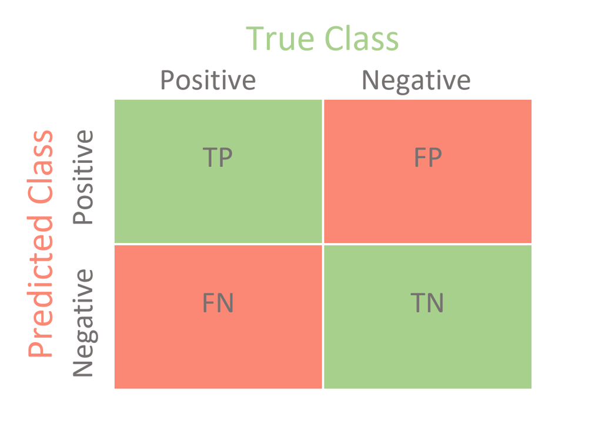

### Training the model

Let’s train Naive Bayes model on training data.

```r
library(quanteda.textmodels)
model.nb = textmodel_nb(train.data, trainY, distribution = "multinomial")
summary(model.nb)
```

```
##
## Call:
## textmodel_nb.dfm(x = train.data, y = trainY, distribution = "multinomial")
##
## Class Priors:
## (showing first 2 elements)
## Negative Positive
##      0.5      0.5
##
## Estimated Feature Scores:
##                  |   online     thank    expert industry     amp      bill
## Negative 0.0010975 0.005293 0.0008718 0.0006523 0.001217 0.01095 0.0006146
## Positive 0.0009764 0.008255 0.0057224 0.0005848 0.001363 0.01202 0.0005012
##              can     case    every    much    paper   price    staff     want
## Negative 0.01022 0.001568 0.001856 0.01221 0.003117 0.02437 0.001869 0.002038
## Positive 0.01155 0.001217 0.001948 0.01213 0.002882 0.01562 0.003180 0.002611
##              work    check    close   crisis     death essential    fight
## Negative 0.006171 0.001167 0.002295 0.007463 0.0011164  0.002590 0.002245
## Positive 0.007268 0.001890 0.002809 0.001305 0.0002715  0.003101 0.001305
##             food     free      fuck      go grocery     hand    hoard     item
## Negative 0.01989 0.000370 0.0017623 0.01280 0.01222 0.002346 0.001806 0.001982
## Positive 0.01295 0.003044 0.0002819 0.01068 0.01482 0.010030 0.001013 0.002235
```

In summary of the model we can see *Estimated Feature Scores* of our features.

### Predicting class for the docs from test set

Let’s calculate predicted classes:

```r
predictedY = predict(model.nb, newdata = test.matched)
```

And the probabilities of the word to be put in either positive or negative tweets:

```r
predicted.prob = round(predict(model.nb, newdata = test.matched, type = "prob"), 2)
```

### Evaluating model performance

Let’s start with evaluation of model performance based on *positive* tweets.

```r
cm.nb.pos = confusionMatrix(data = predictedY, reference = testY, positive="Positive", mode = "prec_recall")
cm.nb.pos
```

```
## Confusion Matrix and Statistics
##
##           Reference
## Prediction Negative Positive
##   Negative     1203      454
##   Positive      336     1350
##
##                Accuracy : 0.7637
##                  95% CI : (0.7489, 0.778)
##     No Information Rate : 0.5396
##     P-Value [Acc > NIR] : < 2.2e-16
##
##                   Kappa : 0.527
##
##  Mcnemar's Test P-Value : 3.145e-05
##
##               Precision : 0.8007
##                  Recall : 0.7483
##                      F1 : 0.7736
##              Prevalence : 0.5396
##          Detection Rate : 0.4038
##    Detection Prevalence : 0.5043
##       Balanced Accuracy : 0.7650
##
##        'Positive' Class : Positive
##
```

We can see that *Recall* is roughly 0.75 that is pretty good results. In general, considering other metrics we can see that we do not have problem of overfitting.

Now let’s consider *negative* tweets

```r
cm.nb.neg = confusionMatrix(data = predictedY, reference = testY, positive="Negative", mode = "prec_recall")
cm.nb.neg
```

```
## Confusion Matrix and Statistics
##
##           Reference
## Prediction Negative Positive
##   Negative     1203      454
##   Positive      336     1350
##
##                Accuracy : 0.7637
##                  95% CI : (0.7489, 0.778)
##     No Information Rate : 0.5396
##     P-Value [Acc > NIR] : < 2.2e-16
##
##                   Kappa : 0.527
##
##  Mcnemar's Test P-Value : 3.145e-05
##
##               Precision : 0.7260
##                  Recall : 0.7817
##                      F1 : 0.7528
##              Prevalence : 0.4604
##          Detection Rate : 0.3599
##    Detection Prevalence : 0.4957
##       Balanced Accuracy : 0.7650
##
##        'Positive' Class : Negative
##
```

We can notice that *Recall* in this case is roughly 0.78 that is even better than in case with positive tweets.

## Anasyis of predictors

Let’s use our classifier for extracting the most important predictors to each class

```r
library(tibble)
vars.nb = t(model.nb$param) %>%
    as.data.frame %>%
    rownames_to_column("word") %>%
    mutate(lo = log(Positive/Negative))
```

Most important predictors for class “Positive”

```r
vars.nb %>% arrange(desc(lo)) %>%  head()
```

|  | word | Negative | Positive | lo |
| --- | --- | --- | --- | --- |
| 1 | love | 1.630636e-04 | 0.001425386 | 2.168058 |
| 2 | free | 3.700289e-04 | 0.003043957 | 2.107333 |
| 3 | happy | 8.780347e-05 | 0.000720525 | 2.104879 |
| 4 | hero | 1.442486e-04 | 0.001075566 | 2.009065 |
| 5 | safe | 5.958093e-04 | 0.004208284 | 1.954890 |
| 6 | special | 1.567919e-04 | 0.001070345 | 1.920817 |

Here we can see that top words are really nice such as *love*, *free*, *happy*. Though they differ from those that were obtained in contrastive analysis part, they still bring the meanings of something positive

Most important predictors for class “Negative”

```r
vars.nb %>% arrange(lo) %>% head()
```

|  | word | Negative | Positive | lo |
| --- | --- | --- | --- | --- |
| 1 | scam | 0.002740723 | 0.0002036266 | -2.599689 |
| 2 | war | 0.001266879 | 0.0001305299 | -2.272709 |
| 3 | shit | 0.001147717 | 0.0001357511 | -2.134707 |
| 4 | collapse | 0.001034827 | 0.0001305299 | -2.070387 |
| 5 | fear | 0.002182543 | 0.0002871658 | -2.028187 |
| 6 | selfish | 0.001235520 | 0.0001670783 | -2.000785 |

As for negative ones, we can see that *scam*, *war*, *shit* are most important here.

### Looking at the errors

Let’s look at the examples where the model does not work correctly

```r
predictions = data.frame(doc_id=as.integer(rownames(predicted.prob)))
predictions$pred_y = predictedY
predictions$pos_prob_pred = predicted.prob[,1]
predictions$neg_prob_pred = predicted.prob[,2]
predictions$true_label = data[rownames(predicted.prob),]$Senti
predictions$text = data[rownames(predicted.prob),]$OriginalTweet

head(predictions)
```

|  | doc_id | pred_y | pos_prob_pred | neg_prob_pred | true_label | text |
| --- | --- | --- | --- | --- | --- | --- |
| 1 | 2714 | Negative | 1.00 | 0.00 | Negative | Indonesia - 227 cases, 19 deaths\r\r\nPhilippines - 187 cases, 14 deaths\r\r\nMalaysia - 673 cases, 2 deaths\r\r\nThailand - 177 cases, 1 death\r\r\nSingapore - 226 cases , 0 deaths\r\r\n\r\r\nIndones… |
| 2 | 6779 | Positive | 0.00 | 1.00 | Positive | It is really nice to see some unsung heroes being realized during this COVID 19 hysteria. \r\r\n\r\r\nGrocery store staff\r\r\nDelivery staff\r\r\nHealthcare staff\r\r\nElderly care staff\r\r\nLogisti… |
| 3 | 16127 | Negative | 0.63 | 0.37 | Positive | COVID-19 cases are now taking off in many states, as lockdowns are coming too late. Today in US: 53,000 cases, almost 10,000 new cases today. In three days, perhaps 100,000 cases; in one week 300,000 … |
| 4 | 2180 | Negative | 0.71 | 0.29 | Negative | @Sideshow_JaneV3 Perhaps... I think the world may be altered in other ways also by COVID-19. More people may want or be forced to work at home. People may find lots of businesses have gone bust, so mo… |
| 5 | 31872 | Negative | 1.00 | 0.00 | Negative | Hypothetically Had Cong been in power during time what could have been the options Mask Scam 700Cr Lab Scam 1000Cr COVID Test Kit Scam 2000Cr JLN Hand Sanitizer Scam 5000Cr Corona Relief Scam 20000Cr … |
| 6 | 369 | Negative | 0.54 | 0.46 | Positive | I know a lot of grocery stores are low on stock of some items. If you need something right away, try the Dollar Store, bodegas, 7-11, drug stores or ask friends/neighbors. I found some things the groc… |

Wrongly predicted negative tweets:

```r
predictions %>% filter(pred_y == 'Positive' & true_label == 'Negative') %>% head()
```

|  | doc_id | pred_y | pos_prob_pred | neg_prob_pred | true_label | text |
| --- | --- | --- | --- | --- | --- | --- |
| 1 | 15500 | Positive | 0.14 | 0.86 | Negative | Covid-19 update:\r\r\n\r\r\nWe understand people need coffee at home, and going into a busy supermarket to buy coffee might worry people. So we are still roasting coffee while following strict hygiene… |
| 2 | 25940 | Positive | 0.33 | 0.67 | Negative | @TuckerCarlson Please clarify, you said it is dumb pandemic-wise to let everyone go to the grocery store, but yet much more damaging to not have every go back to work? That is incoherent to me. More h… |
| 3 | 25006 | Positive | 0.27 | 0.73 | Negative | Two local companies that produce food or distribute goods to grocery stores are stepping up their operations to meet demand caused by the COVID-19 pandemic. Those two companies are McCall Farms and W.… |
| 4 | 29611 | Positive | 0.29 | 0.71 | Negative | In a period of crisis, consumers quickly change their behaviour as they attempt to adapt to the unfolding situation. Using recent data on consumer trends, we share our insights on how Italian consumer… |
| 5 | 11292 | Positive | 0.44 | 0.56 | Negative | @MSNBC Need to be 4 trillion. Cover medical debt, student debt and consumer debt except for cars and mortgages. #coronavirus #relief |
| 6 | 5179 | Positive | 0.40 | 0.60 | Negative | I get the flattening of the curve, but I don't understand the getting rid of the virus if every human being doesn't get tested? Some people show no symptoms. I'm showing no symptoms. People at the gro… |

We can assume that the first tweet here was wrongly predicted due to words *clean* and *thank* that model consider to fit the positive tweets.

```r
vars.nb %>% filter(word == "clean")
```

| word | Negative | Positive | lo |
| --- | --- | --- | --- |
| clean | 0.0006773411 | 0.001456714 | 0.7657633 |

```r
vars.nb %>% filter(word == "thank")
```

| word | Negative | Positive | lo |
| --- | --- | --- | --- |
| thank | 0.000871763 | 0.005722431 | 1.881631 |

Wrongly predicted positive tweets:

```r
predictions %>% filter(pred_y == 'Negative' & true_label == 'Positive') %>% head()
```

|  | doc_id | pred_y | pos_prob_pred | neg_prob_pred | true_label | text |
| --- | --- | --- | --- | --- | --- | --- |
| 1 | 16127 | Negative | 0.63 | 0.37 | Positive | COVID-19 cases are now taking off in many states, as lockdowns are coming too late. Today in US: 53,000 cases, almost 10,000 new cases today. In three days, perhaps 100,000 cases; in one week 300,000 … |
| 2 | 369 | Negative | 0.54 | 0.46 | Positive | I know a lot of grocery stores are low on stock of some items. If you need something right away, try the Dollar Store, bodegas, 7-11, drug stores or ask friends/neighbors. I found some things the groc… |
| 3 | 4465 | Negative | 0.51 | 0.49 | Positive | @DamoPelham @vanOnselenP So clear that every supermarket is raided of food.\r\r\nSo clear that people hire buses to raid supermarkets in country towns and/or other suburbs.\r\r\nSo clear that everyone… |
| 4 | 7065 | Negative | 0.97 | 0.03 | Positive | gt gt gt gt The government will be closing are gas stations down at anytime now if not they ll be hoarding of gas amp our supply will be gone within days when the government controls the gas prices th… |
| 5 | 5488 | Negative | 0.56 | 0.44 | Positive | Don't miss your FREE 72-page land report with an analysis of land prices in 2019, land trends over the last 13 years and we reveal who is buying land. Plus a surge of cattle numbers in marts and #Coro… |
| 6 | 24337 | Negative | 0.64 | 0.36 | Positive | Oh my god I've just been for supplies from a supermarket and people are still going shopping in twos WHY are these people stupid go on your own these people seem to be all over 60 stay at home and pro… |

Here in the second tweet we can assume that the prediction is wrong because of the words *sell* and *low* as they are considered by model to fit in negative tweets

```r
vars.nb %>% filter(word == "sell")
```

| word | Negative | Positive | lo |
| --- | --- | --- | --- |
| sell | 0.002289162 | 0.001639456 | -0.3338216 |

```r
vars.nb %>% filter(word == "low")
```

| word | Negative | Positive | lo |
| --- | --- | --- | --- |
| low | 0.004622226 | 0.001545474 | -1.095546 |

## Logistic Regression

The main idea of logistic regression is to predict class of target variable using probabilities by having the log-odds. It is similar to Naive Bayes algorithm as it also deals with probabilities but the calculations are different.

### Preprocessing

Before we start we need to make some data manipulations

```r
#splitting the data
library(rsample)
set.seed(1991)
tweets_split = data %>%
  select(doc_id) %>%
  initial_split()
train_data_glm = training(tweets_split)
test_data_glm = testing(tweets_split)


#tidy data
tidy_data = data %>%
  unnest_tokens(word, OriginalTweet, token="tweets") %>%
  group_by(word) %>%
  filter(n() > 10) %>%
  ungroup() %>%
  mutate(word = lemmatize_words(word)) %>%
  filter(! word %in% stopwords("en")) %>%
  filter(! str_detect(word, "[0-9]+"))

#sparsing
sparse_words = tidy_data %>%
  count(doc_id, word) %>%
  inner_join(train_data_glm) %>%
  cast_sparse(doc_id, word, n)

#joining
word_rownames = as.integer(rownames(sparse_words))
tweets_joined = data_frame(doc_id = word_rownames) %>%
  left_join(data %>%
    select(doc_id, Senti))
```

For classification with logistic regression we will use function *cv.glmnet* that already includes cross-validation so we need only to specify our training data.

```r
library(glmnet)

is_pos = tweets_joined$Senti == "Positive"
model.glm = cv.glmnet(sparse_words, is_pos,
  family = "binomial",
  keep = TRUE,
  nfolds = 10
)

summary(model.glm)
```

```
##            Length  Class  Mode
## lambda         100 -none- numeric
## cvm            100 -none- numeric
## cvsd           100 -none- numeric
## cvup           100 -none- numeric
## cvlo           100 -none- numeric
## nzero          100 -none- numeric
## call             6 -none- call
## name             1 -none- character
## glmnet.fit      13 lognet list
## fit.preval 2507600 -none- numeric
## foldid       25076 -none- numeric
## lambda.min       1 -none- numeric
## lambda.1se       1 -none- numeric
## index            2 -none- numeric
```

Summary of this model does not tell any story so let’s proceed to analysis of predictors

### Analysis of predictors

We can derive predictors from our model and see what predictors are the most important.

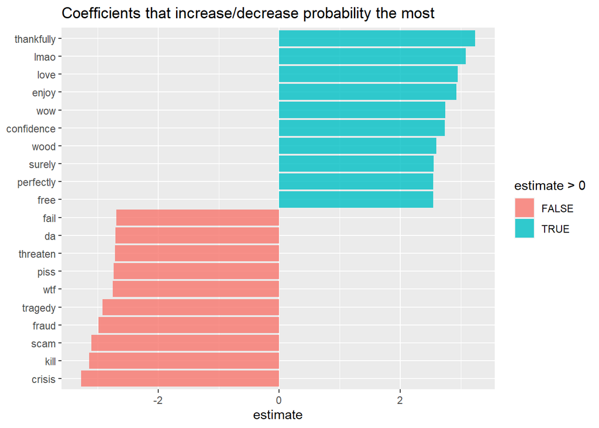

```r
library(broom)
coefs = model.glm$glmnet.fit %>%
  tidy() %>%
  filter(lambda == model.glm$lambda.1se)

library(tidyverse)

coefs %>%
  group_by(estimate > 0) %>%
  top_n(10, abs(estimate)) %>%
  ungroup() %>%
  ggplot(aes(fct_reorder(term, estimate), estimate, fill = estimate > 0)) +
  geom_col(alpha = 0.8, show.legend = TRUE) +
  coord_flip() +
  labs(
    x = NULL,
    title = "Coefficients that increase/decrease probability the most"
  )
```

We can notice that we have some similarities in the results of predictors analysis: *semantically* (by meaning of the words) they are similar. We can even see our lovely **“wtf”** and **“scam”**. In general, we can track similar trend of predictors, so it means that we have good models

### Testing on test data

To test our model on test data we need to pull out the intercept of prediction from the coefficients dataframe and combine with sum of estimates for each word

```r
intercept = coefs %>%
  filter(term == "(Intercept)") %>%
  pull(estimate)

classifications = tidy_data %>%
  inner_join(test_data_glm) %>%
  inner_join(coefs, by = c("word" = "term")) %>%
  group_by(doc_id) %>%
  summarize(score = sum(estimate)) %>%
  mutate(probability = plogis(intercept + score))

head(classifications)
```

| doc_id | score | probability |
| --- | --- | --- |
| 4 | -3.0075686 | 0.04927235 |
| 12 | 2.9153941 | 0.95087891 |
| 14 | 3.6069125 | 0.97478104 |
| 18 | 3.1130572 | 0.95933066 |
| 20 | 3.8694452 | 0.98049046 |
| 25 | -0.9474618 | 0.28910030 |

We can see that we obtained the probabilities of tweets to be positive or negative. Now let’s take a look at ROC curve that helps to understand the model performance evaluation.

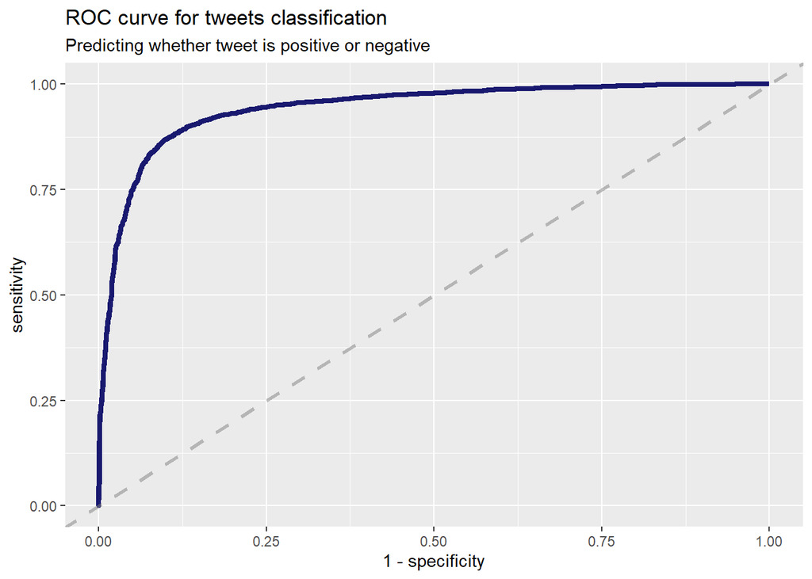

```r
library(yardstick)

comment_classes = classifications %>%
  left_join(data %>%
    select(Senti, doc_id), by = "doc_id") %>%
  mutate(Senti = as.factor(Senti))

comment_classes %>%
  roc_curve(Senti, probability, event_level = "second") %>%
  ggplot(aes(x = 1 - specificity, y = sensitivity)) +
  geom_line(
    color = "midnightblue",
    size = 1.5
  ) +
  geom_abline(
    lty = 2, alpha = 0.5,
    color = "gray50",
    size = 1.2
  ) +
  labs(
    title = "ROC curve for tweets classification",
    subtitle = "Predicting whether tweet is positive or negative"
  )
```

This plot shows us how the sensitivity and specificity are interconnected in our model. We are more interested in *Area Under Curve* (AUC) that is easier for interpretation of model performance evaluation.

```r
comment_classes %>%
  roc_auc(Senti, probability, event_level = "second")
```

| .metric | .estimator | .estimate |
| --- | --- | --- |
| roc_auc | binary | 0.943092 |

We can see pretty good results! It means that logistic regression works well for tweets classification.

### Comparison with Naive Bayes

To compare these results with results from Naive Bayes we can create confusion matrix.

```r
comment_classes %>%
  mutate(
    prediction = case_when(
      probability > 0.5 ~ "Positive",
      TRUE ~ "Negative"
    ),
    prediction = as.factor(prediction)
  ) %>%
  conf_mat(Senti, prediction)
```

```
##           Truth
## Prediction Negative Positive
##   Negative     3385      469
##   Positive      505     3994
```

```r
3385/(3385+505)
```

```
## [1] 0.8701799
```

That’s the end!

[figure not shown]